# Unemployment patterns in the US

Pratistha Dhungana, Marwa Zaki

11/04/25

## Data Summary

The data for unemployment rates of both college graduates and high school graduates come from the U.S. Bureau of Labor Statistics, retrieved from an article from FRED (Federal Reserve Bank of St. Louis). The U.S. Bureau of Labor Statistics collects data through a mix of methods, including surveys sent to households and businesses, electronic data interchange for large firms, and computer-assisted telephone interviews, to gather a variety of data such as employment, wages, and consumer expenditures. The data, also known as the Current Population Survey (CPS), is collected and processed by BLS employees and contractors with strict policies to ensure the confidentiality of respondent information. Further, the data collected for the CPS is a monthly sample survey of around 60,000 households from across the United States; the Census Bureau selected eligible households based on certain steps. They first group all of the counties and independent cities in the U.S. into 2,000 geographic areas, and design and select a sample of around 800 areas (units) to represent each state (and D.C.); these areas are intended to reflect a various range, including urban and rural areas, as well as various industrial and farming regions. The Census Bureau does note that their sample excludes individuals living in institutions and those on active duty in the Armed Forces. However, overall, any person over the age of sixteen is eligible to be selected for the survey (“Current Population Survey”). According to the Labor Force Statistics from the CPS, much of the data collected can often undergo seasonal adjustments to account for fluctuations over the course of year as a result of seasonal events. However, both of the datasets used for this paper have not undergone any form of seasonal adjustments. The data does experience modifications for population control. Specifically, the Census Bureau adjusts the CPS population controls to incorporate the latest information about population change, and these adjustments are incorporated into the CPS estimates for data in January (“Technical Documentation (CPS)”). One of the main potential issues the data could pose is regarding its status as sample data. While it may be designed to be nationally representative, a sample is not a complete count of the U.S. population, meaning it is subject to random variation and sampling error. The impact of this is that reported unemployment rates can differ from the true population value, particularly for small subgroups like education level, which may affect comparison between the two groups. Additionally, there is an issue with how the CPS defines unemployment. According to the BLS, a person who is unemployed is characterized as someone who is jobless, looking for a job, and available for work (U.S. Bureau of Labor Statistics). This definition can exclude a large number of individuals, including discouraged workers who are unemployed but are not actively seeking employment. As a result, the collected unemployment rates may underrepresent the true values for the two groups. Despite this, the collected data remains appropriate for answering our outlined research question, largely because the CPS is a major primary source for U.S. labor force statistics. It collects detailed data that distinguishes between the levels of educational attainment (those with a bachelor’s degree or higher vs. those with a high school degree or lower), allowing for a direct comparison of unemployment rates between the two groups. Additionally, because this data is collected monthly, it can successfully break down the single year that the research question focuses on (2024) with by-month data.

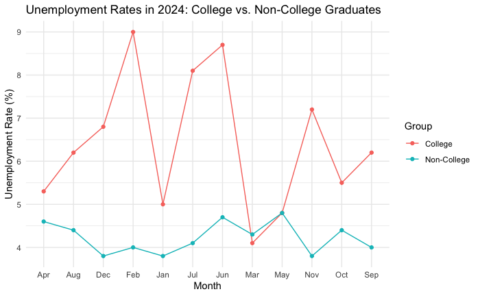

```r
# Loading and Renaming data sets
library(tidyverse)
college<-read.csv("college.1.csv")
non.college <- read.csv("highschool.csv")

colnames(college) <- c("Month", "UR_College")
colnames(non.college) <- c("Month", "UR_NonCollege")

# Changing the months column to display month names
college$Month <- month.name[as.numeric(substr(college$Month, 6,7))]
non.college$Month <- month.name[as.numeric(substr(non.college$Month, 6,7))]

# Merging data
unemployment.data <- merge(college, non.college, by="Month")
unemployment.data$Month <- c("Jan", "Feb", "Mar", "Apr", "May", "Jun", "Jul", "Aug",
                             "Sep", "Oct", "Nov", "Dec")


# Line Plot of Unemployment

ggplot(unemployment.data, aes(x=Month)) +
  geom_line(aes(y=UR_College, color="College", group=1)) +
  geom_line(aes(y=UR_NonCollege, color = "Non-College", group=1)) +
  geom_point(aes(y=UR_College, color="College")) +
  geom_point(aes(y=UR_NonCollege, color = "Non-College")) +
  labs(
    title = "Unemployment Rates in 2024: College vs. Non-College Graduates",
    x = "Month",
    y = "Unemployment Rate (%)",
    color = "Group") +
  theme_minimal()
```

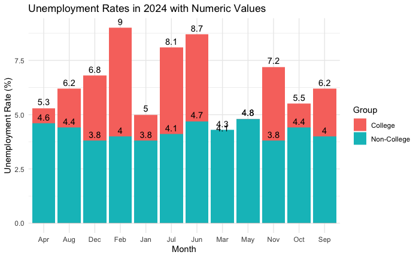

```r
# Bar Graph
ggplot(unemployment.data, aes(x=Month)) +
  geom_col(aes(y=UR_College, fill = "College"), position = "dodge") +
  geom_col(aes(y=UR_NonCollege, fill = "Non-College"), position = "dodge") +
  geom_text(aes(y=UR_College, label = UR_College), vjust = -0.5, color="black") +
  geom_text(aes(y=UR_NonCollege, label = UR_NonCollege), vjust = -0.5, color="black") +
  labs(
    title = "Unemployment Rates in 2024 with Numeric Values",
    x = "Month",
    y = "Unemployment Rate (%)",
    fill = "Group") +
  theme_minimal()
```

## Numerical summaries

```r
summary(unemployment.data[,c("UR_College", "UR_NonCollege")])
```

```
   UR_College    UR_NonCollege
 Min.   :4.100   Min.   :3.800
 1st Qu.:5.225   1st Qu.:3.950
 Median :6.200   Median :4.200
 Mean   :6.408   Mean   :4.225
 3rd Qu.:7.425   3rd Qu.:4.450
 Max.   :9.000   Max.   :4.800
```

## Average unemployment by education level

```r
avg_college <- mean(unemployment.data$UR_College)
avg_noncollege <- mean(unemployment.data$UR_NonCollege)

avg_college; avg_noncollege
```

```
[1] 6.408333
[1] 4.225
```

## Data Appendix

```r
head(unemployment.data, 12)
```

|  | Month | UR_College | UR_NonCollege |
| --- | --- | --- | --- |
| 1 | Jan | 5.0 | 3.8 |
| 2 | Feb | 9.0 | 4.0 |
| 3 | Mar | 4.1 | 4.3 |
| 4 | Apr | 5.3 | 4.6 |
| 5 | May | 4.8 | 4.8 |
| 6 | Jun | 8.7 | 4.7 |
| 7 | Jul | 8.1 | 4.1 |
| 8 | Aug | 6.2 | 4.4 |
| 9 | Sep | 6.2 | 4.0 |
| 10 | Oct | 5.5 | 4.4 |

[output cut: 2 more lines]

## References

- U.S. Bureau of Labor Statistics. *Labor Force Statistics from the Current Population Survey.* https://www.bls.gov/cps/
- Federal Reserve Bank of St. Louis. *FRED Economic Data.* Series: LNU04027660, CGBD2024. https://fred.stlouisfed.org/
- U.S. Census Bureau. *Technical Documentation for the Current Population Survey (CPS).*